# Practical Machine Learning Project

Johan Larsson B

26 december 2015

# Summary

This report describes the Course Project Writeup assignment as part of the Coursera Practical Machine Learning course. The task is to use Machine Learning to classify exercises from fitness device data, collected and classified by a group of enthusiasts. The group of six participants had accelerometers on the belt, forearm, arm, and dumbell and performed barbell lifts correctly and incorrectly in five different ways. After cleaning the data, a Random Forest model with 0.79% out-of-sample rate is selected for prediction of the exercises in the testing data.

# Getting and Cleaning Data

The [training](https://d396qusza40orc.cloudfront.net/predmachlearn/pml-training.csv) and [test](https://d396qusza40orc.cloudfront.net/predmachlearn/pml-testing.csv) data were downloaded to local folder, to avoid accessing the server multiple times, before it was loaded.

```r
setwd("~/Coursera/The Data Science Specialization/8 Practical Machine Learning/Project/")
rawtraining <- read.csv("pml-training.csv", header = TRUE, sep = ",")
rawtesting <- read.csv("pml-testing.csv", header = TRUE, sep = ",")
```

The training data contains 19622 rows and 160 columns. Running the summary function on the first 19 columns of the training and testing sets gives a hinch about the data.

```r
summary(rawtraining[ , 1:19])
```

```
##        X            user_name    raw_timestamp_part_1 raw_timestamp_part_2
##  Min.   :    1   adelmo  :3892   Min.   :1.322e+09    Min.   :   294
##  1st Qu.: 4906   carlitos:3112   1st Qu.:1.323e+09    1st Qu.:252912
##  Median : 9812   charles :3536   Median :1.323e+09    Median :496380
##  Mean   : 9812   eurico  :3070   Mean   :1.323e+09    Mean   :500656
##  3rd Qu.:14717   jeremy  :3402   3rd Qu.:1.323e+09    3rd Qu.:751891
##  Max.   :19622   pedro   :2610   Max.   :1.323e+09    Max.   :998801
##
##           cvtd_timestamp  new_window    num_window      roll_belt
##  28/11/2011 14:14: 1498   no :19216   Min.   :  1.0   Min.   :-28.90
##  05/12/2011 11:24: 1497   yes:  406   1st Qu.:222.0   1st Qu.:  1.10
##  30/11/2011 17:11: 1440               Median :424.0   Median :113.00
##  05/12/2011 11:25: 1425               Mean   :430.6   Mean   : 64.41
##  02/12/2011 14:57: 1380               3rd Qu.:644.0   3rd Qu.:123.00
##  02/12/2011 13:34: 1375               Max.   :864.0   Max.   :162.00
##  (Other)         :11007
##    pitch_belt          yaw_belt       total_accel_belt kurtosis_roll_belt
##  Min.   :-55.8000   Min.   :-180.00   Min.   : 0.00             :19216
##  1st Qu.:  1.7600   1st Qu.: -88.30   1st Qu.: 3.00    #DIV/0!  :   10
##  Median :  5.2800   Median : -13.00   Median :17.00    -1.908453:    2
##  Mean   :  0.3053   Mean   : -11.21   Mean   :11.31    -0.016850:    1
##  3rd Qu.: 14.9000   3rd Qu.:  12.90   3rd Qu.:18.00    -0.021024:    1
##  Max.   : 60.3000   Max.   : 179.00   Max.   :29.00    -0.025513:    1
##                                                        (Other)  :  391
##  kurtosis_picth_belt kurtosis_yaw_belt skewness_roll_belt
##           :19216            :19216              :19216
##  #DIV/0!  :   32     #DIV/0!:  406     #DIV/0!  :    9
##  47.000000:    4                       0.000000 :    4
##  -0.150950:    3                       0.422463 :    2
##  -0.684748:    3                       -0.003095:    1
##  -1.750749:    3                       -0.010002:    1
##  (Other)  :  361                       (Other)  :  389
##  skewness_roll_belt.1 skewness_yaw_belt max_roll_belt     max_picth_belt
##           :19216             :19216     Min.   :-94.300   Min.   : 3.00
##  #DIV/0!  :   32      #DIV/0!:  406     1st Qu.:-88.000   1st Qu.: 5.00
##  0.000000 :    4                        Median : -5.100   Median :18.00
##  -2.156553:    3                        Mean   : -6.667   Mean   :12.92
##  -3.072669:    3                        3rd Qu.: 18.500   3rd Qu.:19.00
##  -6.324555:    3                        Max.   :180.000   Max.   :30.00
##  (Other)  :  361                        NA's   :19216     NA's   :19216
```

```r
summary(rawtesting[ , 1:19])
```

```
##        X            user_name raw_timestamp_part_1 raw_timestamp_part_2
##  Min.   : 1.00   adelmo  :1   Min.   :1.322e+09    Min.   : 36553
##  1st Qu.: 5.75   carlitos:3   1st Qu.:1.323e+09    1st Qu.:268655
##  Median :10.50   charles :1   Median :1.323e+09    Median :530706
##  Mean   :10.50   eurico  :4   Mean   :1.323e+09    Mean   :512167
##  3rd Qu.:15.25   jeremy  :8   3rd Qu.:1.323e+09    3rd Qu.:787738
##  Max.   :20.00   pedro   :3   Max.   :1.323e+09    Max.   :920315
##
##           cvtd_timestamp new_window   num_window      roll_belt
##  30/11/2011 17:11:4      no:20      Min.   : 48.0   Min.   : -5.9200
##  05/12/2011 11:24:3                 1st Qu.:250.0   1st Qu.:  0.9075
##  30/11/2011 17:12:3                 Median :384.5   Median :  1.1100
##  05/12/2011 14:23:2                 Mean   :379.6   Mean   : 31.3055
##  28/11/2011 14:14:2                 3rd Qu.:467.0   3rd Qu.: 32.5050
##  02/12/2011 13:33:1                 Max.   :859.0   Max.   :129.0000
##  (Other)         :5
##    pitch_belt         yaw_belt      total_accel_belt kurtosis_roll_belt
##  Min.   :-41.600   Min.   :-93.70   Min.   : 2.00    Mode:logical
##  1st Qu.:  3.013   1st Qu.:-88.62   1st Qu.: 3.00    NA's:20
##  Median :  4.655   Median :-87.85   Median : 4.00
##  Mean   :  5.824   Mean   :-59.30   Mean   : 7.55
##  3rd Qu.:  6.135   3rd Qu.:-63.50   3rd Qu.: 8.00
##  Max.   : 27.800   Max.   :162.00   Max.   :21.00
##
##  kurtosis_picth_belt kurtosis_yaw_belt skewness_roll_belt
##  Mode:logical        Mode:logical      Mode:logical
##  NA's:20             NA's:20           NA's:20
##
##
##
##
##
##  skewness_roll_belt.1 skewness_yaw_belt max_roll_belt  max_picth_belt
##  Mode:logical         Mode:logical      Mode:logical   Mode:logical
##  NA's:20              NA's:20           NA's:20        NA's:20
##
##
##
##
##
```

The first column (X) contains an index to each row in the file and is not relevant for the classification. No time window analysis will be done, so the “time” columns are also obsolete. Next, the new_window is mostly empty in the training data, and since it is completely empty in the testing data it can be removed. The num_window column is most likely an artifact from post-processing of the data, and may on it’s own serve as a single predictor in a model, which is kind of cheating even though fully alllowed to be used according to the instructions.A great number of variables are mainly either empty or contain mainly NAs, and seem to be aggregated data of other records. In the testing data these variables are either empty or contain only NAs, so these are removed as well. These aggregated variables start with “min_”, “max_”, “kurtosis_”, “skewness_”, “var_”, “avg_”, “stdev_” and “amplitude_”.

```r
not_columns <- grep("^X|min_|max_|new_|num_|avg_|var_|stddev_|kurtosis_|skewness_|amplitude_|.*_timestamp", colnames(rawtraining), perl = TRUE, value = FALSE)
rows <- is.na(rawtraining$max_roll_belt)
training <- rawtraining[rows, -not_columns]
colnames(training)
```

```
##  [1] "user_name"            "roll_belt"            "pitch_belt"
##  [4] "yaw_belt"             "total_accel_belt"     "gyros_belt_x"
##  [7] "gyros_belt_y"         "gyros_belt_z"         "accel_belt_x"
## [10] "accel_belt_y"         "accel_belt_z"         "magnet_belt_x"
## [13] "magnet_belt_y"        "magnet_belt_z"        "roll_arm"
## [16] "pitch_arm"            "yaw_arm"              "total_accel_arm"
## [19] "gyros_arm_x"          "gyros_arm_y"          "gyros_arm_z"
## [22] "accel_arm_x"          "accel_arm_y"          "accel_arm_z"
## [25] "magnet_arm_x"         "magnet_arm_y"         "magnet_arm_z"
## [28] "roll_dumbbell"        "pitch_dumbbell"       "yaw_dumbbell"
## [31] "total_accel_dumbbell" "gyros_dumbbell_x"     "gyros_dumbbell_y"
## [34] "gyros_dumbbell_z"     "accel_dumbbell_x"     "accel_dumbbell_y"
## [37] "accel_dumbbell_z"     "magnet_dumbbell_x"    "magnet_dumbbell_y"
## [40] "magnet_dumbbell_z"    "roll_forearm"         "pitch_forearm"
## [43] "yaw_forearm"          "total_accel_forearm"  "gyros_forearm_x"
## [46] "gyros_forearm_y"      "gyros_forearm_z"      "accel_forearm_x"
## [49] "accel_forearm_y"      "accel_forearm_z"      "magnet_forearm_x"
## [52] "magnet_forearm_y"     "magnet_forearm_z"     "classe"
```

The cleaned data has 19216 rows and 54 columns.

# Evaluate Machine Learning algorithms

## Preparations

Load the required packages, e.g caret.

```r
library(caret)
library(ggplot2)
library(rpart)
library(rattle)
```

Divide training into train and test set using the train/test proportions 60/40.

```r
set.seed(1234)
inTrain <- createDataPartition(y=training$classe, p=0.6, list=FALSE)
train <- training[inTrain, ]; test <- training[-inTrain, ]
```

## Modeling with Trees

The first approach is to use a classification tree model.

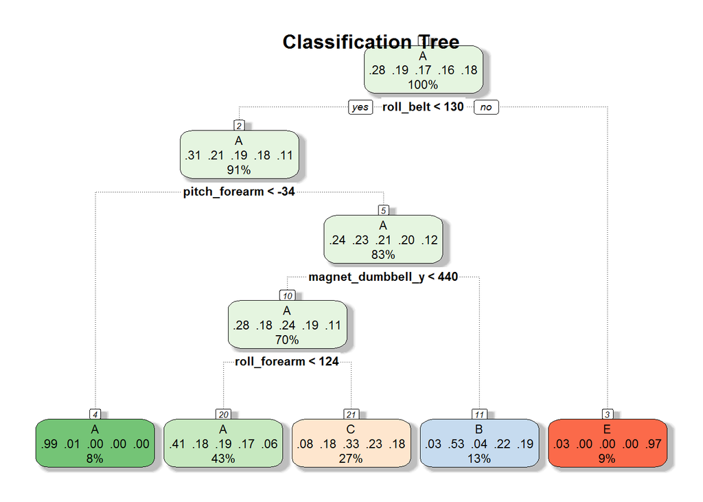

```r
set.seed(1234)
modFit_rpart <- train(classe ~ ., data = train, method = "rpart")
fancyRpartPlot(modFit_rpart$finalModel, main = "Classification Tree", sub="")
```

```r
pred_rpart <- predict(modFit_rpart, newdata = test)
cm_rpart <- confusionMatrix(pred_rpart, test$classe); cm_rpart
```

```
## Confusion Matrix and Statistics
##
##           Reference
## Prediction    A    B    C    D    E
##          A 1966  660  629  584  192
##          B   40  475   49  231  181
##          C  146  352  662  443  359
##          D    0    0    0    0    0
##          E   36    0    0    0  679
##
## Overall Statistics
##
##                Accuracy : 0.4922
##                  95% CI : (0.481, 0.5034)
##     No Information Rate : 0.2847
##     P-Value [Acc > NIR] : < 2.2e-16
##
##                   Kappa : 0.3357
##  Mcnemar's Test P-Value : NA
##
## Statistics by Class:
##
##                      Class: A Class: B Class: C Class: D Class: E
## Sensitivity            0.8985  0.31944  0.49403   0.0000  0.48122
## Specificity            0.6243  0.91915  0.79508   1.0000  0.99426
## Pos Pred Value         0.4877  0.48668  0.33741      NaN  0.94965
## Neg Pred Value         0.9392  0.84914  0.88151   0.8363  0.89496
## Prevalence             0.2847  0.19352  0.17439   0.1637  0.18363
## Detection Rate         0.2559  0.06182  0.08615   0.0000  0.08837
## Detection Prevalence   0.5246  0.12702  0.25534   0.0000  0.09305
## Balanced Accuracy      0.7614  0.61929  0.64456   0.5000  0.73774
```

This model does not perform very well with almost 50.7808433% out-of-sample errors.

## Modeling with Random Forests

The second approach is to use a Random Forests model. As a starting point, the deafult options is used for bootstrapping and pre-processing like Principal Component Analysis (PCA) is not used either.

```r
set.seed(1234)
modFit_rf <- train(classe ~ ., data = train, method = "rf")
modFit_rf$finalModel
```

```
##
## Call:
##  randomForest(x = x, y = y, mtry = param$mtry)
##                Type of random forest: classification
##                      Number of trees: 500
## No. of variables tried at each split: 29
##
##         OOB estimate of  error rate: 0.91%
## Confusion matrix:
##      A    B    C    D    E class.error
## A 3279    3    0    0    1 0.001218398
## B   21 2200    8    2    0 0.013895114
## C    0   20 1982   10    0 0.014910537
## D    0    0   20 1865    4 0.012705135
## E    0    2    6    8 2101 0.007557865
```

```r
pred_rf <- predict(modFit_rf, newdata = test)
cm_rf <- confusionMatrix(pred_rf, test$classe); cm_rf
```

```
## Confusion Matrix and Statistics
##
##           Reference
## Prediction    A    B    C    D    E
##          A 2187   14    0    0    0
##          B    1 1470   13    0    0
##          C    0    3 1323   18    1
##          D    0    0    4 1240    7
##          E    0    0    0    0 1403
##
## Overall Statistics
##
##                Accuracy : 0.9921
##                  95% CI : (0.9898, 0.9939)
##     No Information Rate : 0.2847
##     P-Value [Acc > NIR] : < 2.2e-16
##
##                   Kappa : 0.99
##  Mcnemar's Test P-Value : NA
##
## Statistics by Class:
##
##                      Class: A Class: B Class: C Class: D Class: E
## Sensitivity            0.9995   0.9886   0.9873   0.9857   0.9943
## Specificity            0.9975   0.9977   0.9965   0.9983   1.0000
## Pos Pred Value         0.9936   0.9906   0.9836   0.9912   1.0000
## Neg Pred Value         0.9998   0.9973   0.9973   0.9972   0.9987
## Prevalence             0.2847   0.1935   0.1744   0.1637   0.1836
## Detection Rate         0.2846   0.1913   0.1722   0.1614   0.1826
## Detection Prevalence   0.2864   0.1931   0.1750   0.1628   0.1826
## Balanced Accuracy      0.9985   0.9932   0.9919   0.9920   0.9972
```

The out-of-sample errors for this model is 0.7938574%. This is good enough for prediction of 20 samples, so no attempt is made to improve the model by altering the default options in the training, to perform PCA or to redo the training with the entire training data set.

## Modeling with num_window as single predictor

In the data cleaning phase, the num_window variable was excluded as a predictor due to the suspicion that it was an artifact of the data collection and highly correlated with the classe variable.

```r
columns_sp <- grep("^num_|new_|classe", colnames(rawtraining), perl = TRUE, value = FALSE)
training_sp <- rawtraining[rows, columns_sp]
set.seed(1234)
inTrain_sp <- createDataPartition(y=training_sp$classe, p=0.6, list=FALSE)
train_sp <- training_sp[inTrain_sp, ]; test_sp <- training_sp[-inTrain_sp, ]
set.seed(1234)
modFit_rf_sp <- train(classe ~ ., data = train_sp, method = "rf")
pred_rf_sp <- predict(modFit_rf_sp, newdata = test_sp)
cm_rf_sp <- confusionMatrix(pred_rf_sp, test_sp$classe); cm_rf_sp
```

```
## Confusion Matrix and Statistics
##
##           Reference
## Prediction    A    B    C    D    E
##          A 2188    0    0    0    0
##          B    0 1486    0    0    0
##          C    0    0 1340    0    0
##          D    0    0    0 1258    0
##          E    0    1    0    0 1411
##
## Overall Statistics
##
##                Accuracy : 0.9999
##                  95% CI : (0.9993, 1)
##     No Information Rate : 0.2847
##     P-Value [Acc > NIR] : < 2.2e-16
##
##                   Kappa : 0.9998
##  Mcnemar's Test P-Value : NA
##
## Statistics by Class:
##
##                      Class: A Class: B Class: C Class: D Class: E
## Sensitivity            1.0000   0.9993   1.0000   1.0000   1.0000
## Specificity            1.0000   1.0000   1.0000   1.0000   0.9998
## Pos Pred Value         1.0000   1.0000   1.0000   1.0000   0.9993
## Neg Pred Value         1.0000   0.9998   1.0000   1.0000   1.0000
## Prevalence             0.2847   0.1935   0.1744   0.1637   0.1836
## Detection Rate         0.2847   0.1934   0.1744   0.1637   0.1836
## Detection Prevalence   0.2847   0.1934   0.1744   0.1637   0.1838
## Balanced Accuracy      1.0000   0.9997   1.0000   1.0000   0.9999
```

The out-of-sample errors is 0.0130141%, i.e. almost perfect classification, which confirms the suspicion that this is highly correlated with the classe variable. USing this as a predictor in the model would lead to problems when predicting the classe variable on new data.

# Prediction for the Course Project Submission

The prediction of the classe variable in the pm-testing.csv is done using the Random Forests model.

```r
testing <- rawtesting[rows, -not_columns]
pred_subm <- predict(modFit_rf, newdata = testing)
```

The files for the Course Project submission is generated using the code supplemented in the assignment.

```r
pml_write_files = function(x){
  n = length(x)
  for(i in 1:n){
    filename = paste0("problem_id_",i,".txt")
    write.table(x[i],file=filename,quote=FALSE,row.names=FALSE,col.names=FALSE)
  }
}
answers <- as.character(pred_subm); answers
```

```
##  [1] "B" "A" "B" "A" "A" "E" "D" "B" "A" "A" "B" "C" "B" "A" "E" "E" "A"
## [18] "B" "B" "B"
```

```r
pml_write_files(answers)
```